# Fitting a Spatio-temporal model with `inlabru`

Day 2, Morning

Instructor: Sara Martino

In this practical we are going to fit a spatio-temporal model for the daily PM10 concentration in Piemonte (Italy).

This is a semplifued version of the model presented in (Cameletti et al. 2013).

The goals of this practical are:

- Learn how to fit a spatio-temporal model in `inlabru`
- Learn how to do predictions
- Learn how to simulate from the fitted model

Start by loading useful libraries:

```r
library(INLA)
library(ggplot2)
library(patchwork)
# load some libraries to generate nice map plots
library(inlabru)
library(tidyverse)
library(sp)
library(sf)
library(viridis)
library(raster)

knitr::opts_knit$set(root.dir = "~/INLA_course/Practicals/")
```

# 1 The data

In this exercise we will consider only the first 50 days to make the model run faster. You are free to run the model on the complete dataset if you so wish.

Start by loading the data

```r
# read data ---------------------------------------------------------------
df = read.table("Data/PM10_Piemonte/Piemonte_data.dat")

# select only the first 50 days
df = df[df$time<=50,]

df[1:5,]
```

```
##   Station.ID       Date   dem      x       y   WS   temp   HMIX PREC   EMI PM10
## 1          1 2005-10-01  95.2 469.45 4972.85 0.90 288.81 1294.6    0 26.05   28
## 2          2 2005-10-01 164.1 423.48 4950.69 0.82 288.67 1139.8    0 18.74   22
## 3          3 2005-10-01 242.9 490.71 4948.86 0.96 287.44 1404.0    0  6.28   17
## 4          4 2005-10-01 149.9 437.36 4973.34 1.17 288.63 1042.4    0 29.35   25
## 5          5 2005-10-01 405.0 426.44 5045.66 0.60 287.63 1038.7    0 32.19   20
##   time  logPM10
## 1    1 3.332205
## 2    1 3.091042
## 3    1 2.833213
## 4    1 3.218876
## 5    1 2.995732
```

The data consist in the PM10 concentrations (`PM10`), the time (`time`), the station locations (`x` and `y`) and some covariates. Here we will consider only the altitude (`dem`) which is fixed in time and the temperature (`temp`) which varies in both space and time.

We load also a shapefile representing the Piemonte region:

```r
# area of interest
shape = readRDS("Data/PM10_Piemonte/Piemonte")
```

Let’s look at the PM10 concentrations in the fist 6 days in the dataset

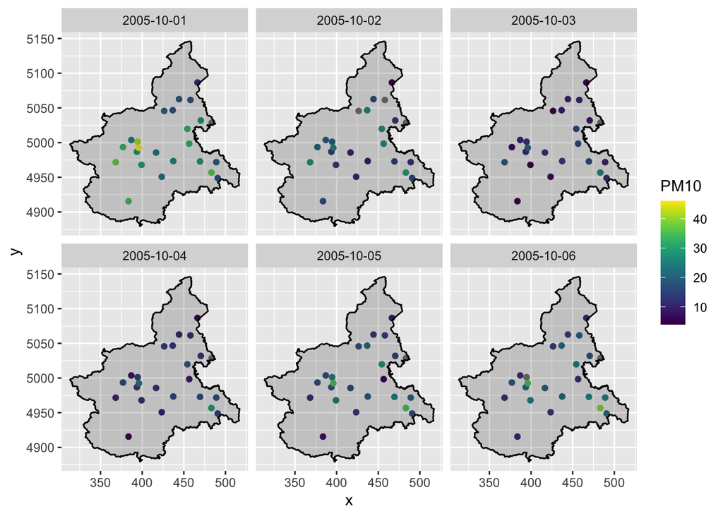

```r
df %>% dplyr::filter(time<7) %>%
  ggplot() + geom_point(aes(x,y,color = PM10)) +
   facet_wrap(.~Date) + gg(data = shape) + scale_color_viridis()
```

**Exercise 1:** Explore the dataset. Is a Gaussian likelihood reasonable or should we consider a transformation of the PM10 concentrations? Do we have reason to believe that elevation and temperature explain (part) of the variability in the PM10 variable?

# 2 The model

We model the log PM10 concentration:

$$\begin{aligned}
y_{it}&\sim\mathcal{N}(\eta_it, \sigma^2_e)\\
\eta_{it}& = \alpha + \beta_1\text{dem}_i + \beta_2\text{temp}_{it} + \omega_{it}
\end{aligned}$$

- $y_{it}$ is the log-concentration at location $i$ in time $t$
- $\alpha$ is an intercept
- $\beta_1$ and $\beta_2$ parameters of altitude and temperature
- $\omega_{it}$ is the space-time residual

For the spatio-temporal residual process $\omega_{it}$, we assume first order autoregressive process with spatially colored innovations

$$\omega_{it} = a \omega_{i(t-1)}+\xi_{it}$$

- $|a|<1$ parameter of the AR1 process
- $\xi_{it}$ is a zero mean, temporally independent, Gaussian field with

$$\text{Cov}(\xi_{it},\xi_{ju}) =
\begin{cases}
0 ,& \text{ if } t\neq u \\
\mathcal{C}(h),& \text{ if } t= u
\end{cases}$$

# 3 Create the mesh

First thing to do is to create the mesh for the SPDE representation

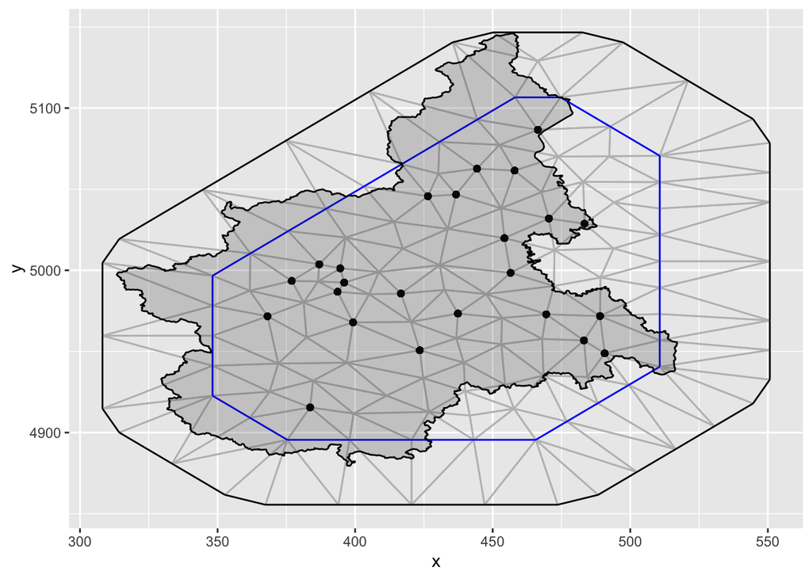

```r
# create the mesh
mesh = inla.mesh.2d(loc = cbind(df$x, df$y),
                    offset = c(20,40),
                    max.edge = c(30,50))
ggplot() + gg(mesh) + geom_point(data = df, aes(x,y)) +
  gg(shape)
```

Since it is a space-time model and there are not too many observation stations, we choose a quite rough mesh.

# 4 The SPDE model

Next we need to define the SPDE model:

```r
spde = inla.spde2.pcmatern(mesh = mesh,
                           prior.range=c(100,0.5),
                           prior.sigma=c(1,0.1))
```

Here we assume that in the prior

- $\text{Prob}(\rho<100\text{ Km}) = 0.5$
- $\text{Prob}(\sigma>1) = 0.1$

# 5 Run the model

To implement the model for the spatio-temporal residual field $\omega_{it}$ we need to use the `group` option when defining the `SPDE` component:

```r
# make the data a spatial object
coordinates(df) = c("x","y")

# model component
cmp  = ~ Intercept(1) +
  SPDE(coordinates, model = spde,
       group = time, control.group = list(model = "ar1")) +
  dem(dem, model = "linear") +
  temp(temp, model = "linear")

# likelihood
lik = like(formula = logPM10 ~ Intercept + SPDE + dem + temp ,
           family = "gaussian",
           data = df)

# fit the model
fit = bru(cmp, lik,
          options = list(verbose = F,
                         bru_max_iter = 1,
                         inla.mode  = "experimental"))
```

**Exercise 2:** Explore the fitted model. What is the effect of the covariates? Plot the posterior marginal for the model hyperparameters.

# 6 Prediction surfaces

We want to predict the concentration (not the log concentration!) of PM10 in Piemonte for the first 5 days in our dataset. To do this we need the values of the altitude and temperature for every point of interest in both space and time.

Start by reading the altitude model

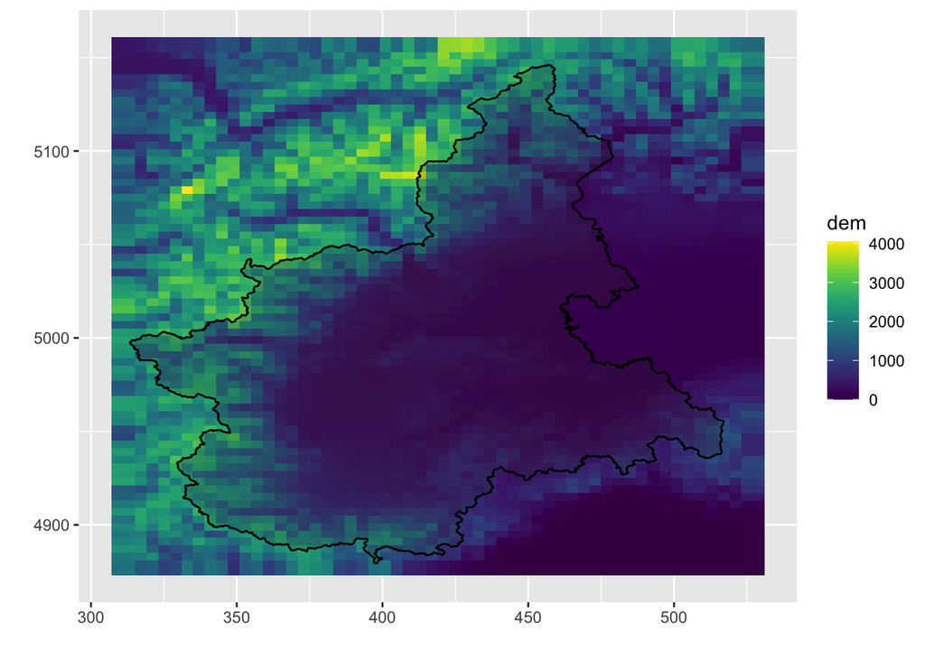

```r
alt = read.table("Data/PM10_Piemonte/Altitude.dat")
dem = SpatialPixelsDataFrame(points = cbind(alt[,1],
                                            alt[,2]),
                             data = data.frame(dem = alt[,3]))
ggplot() + gg(dem) + scale_fill_viridis() +
  xlab("") + ylab("") + gg(shape)
```

and the temperature

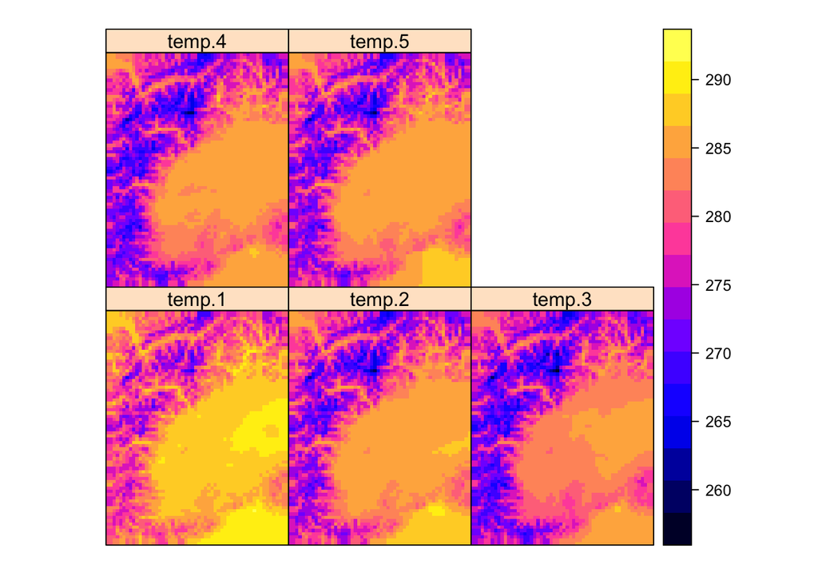

```r
# temperature (this is time varying)
load("Data/PM10_Piemonte/Temp_GRID.Rdata")
temp = Mean_Temp[,,1:5]

mat = matrix(NA, dim(temp)[1]*dim(temp)[2], 5)
for(i in 1:5)
  mat[,i] =  as.vector(t(temp[,,i]))


temp = SpatialPixelsDataFrame(points = alt[,c(1,2)],
                              data = data.frame(temp = mat))
sp::spplot(temp)
```

We want to “enlarge” the domain of the covariates so that they cover all the mesh points. To do this we can use the `bru_fill_missing` function.

We can do this for the altitude:

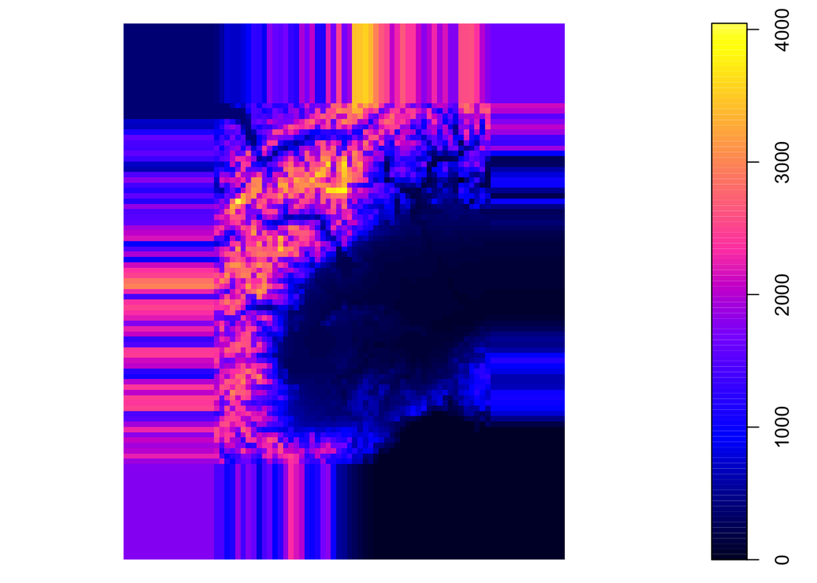

```r
## create another object which  does cover the whole mesh
large_grid = expand_grid(x = seq(250, 580,4),
                         y = seq(4810, 5210,4))


## create an altitude model over the large grid
dem_large = SpatialPixelsDataFrame(points = large_grid,
                                   data = data.frame(dem =
                                                       rep(NA,length(large_grid$x))))

# Use bru_fill_missing to fill the new object
dem_large$dem <- bru_fill_missing(data = dem,
                                  where = dem_large,
                                  values = dem_large$dem)

plot(dem_large)
```

And for the temperature:

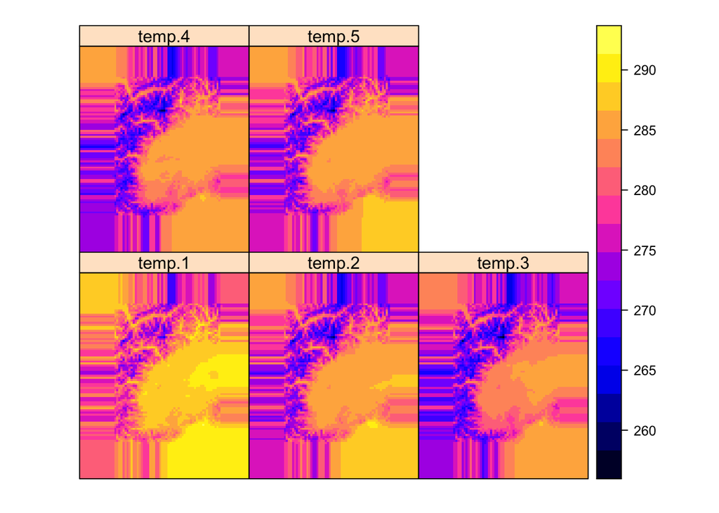

```r
temp_large = SpatialPixelsDataFrame(points = cbind(large_grid$x,
                                                   large_grid$y),
                                    data = data.frame(temp = matrix(NA,
                                                                    length(large_grid$x),5)))

# Use bru_fill_missing to fill the new object
fill_names = names(temp)
for (layer in fill_names) {
  temp_large[[layer]] <- bru_fill_missing(temp,
                                          temp_large,
                                          values = temp_large[[layer]],
                                          layer = layer)
}
sp::spplot(temp_large)
```

We can now sample from the fitted model in order to inspect the surfaces in log scale and the SPDE model. To do this we first create a space-time grid and the use the `generate()` function. Note that this function, as also the `predict()` function, can give several outputs at the same time:

```r
# define prediction area --------------------------------------------------
pxl = pixels(mesh, nx = 200, ny = 200, mask = shape)
ips2 <- ipoints(domain = c(1:5), name = "time")

pxl_time <- cbind(cprod(pxl,ips2), data.frame(temp = 0))

samples = generate(fit, pxl_time,
        ~data.frame(
          log_scale = Intercept +
                       SPDE +
                       dem_eval(inlabru:::eval_SpatialDF(dem_large,
                                                         .data.)) +
                       temp_eval(inlabru:::eval_SpatialDF(temp_large,
                                               .data.,
                                               selector = "time")),
          spde =  SPDE ),
        n.samples = 2)
```

We can now plot the result

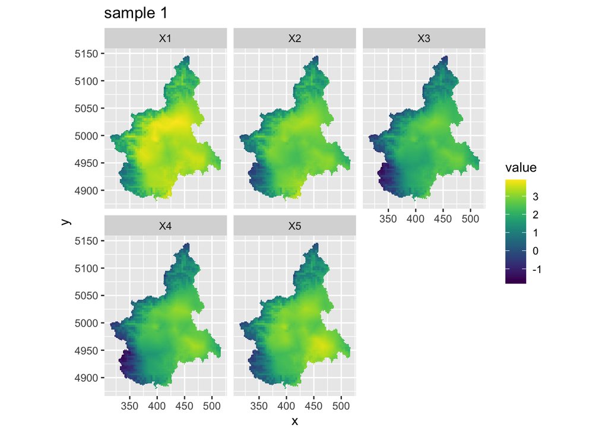

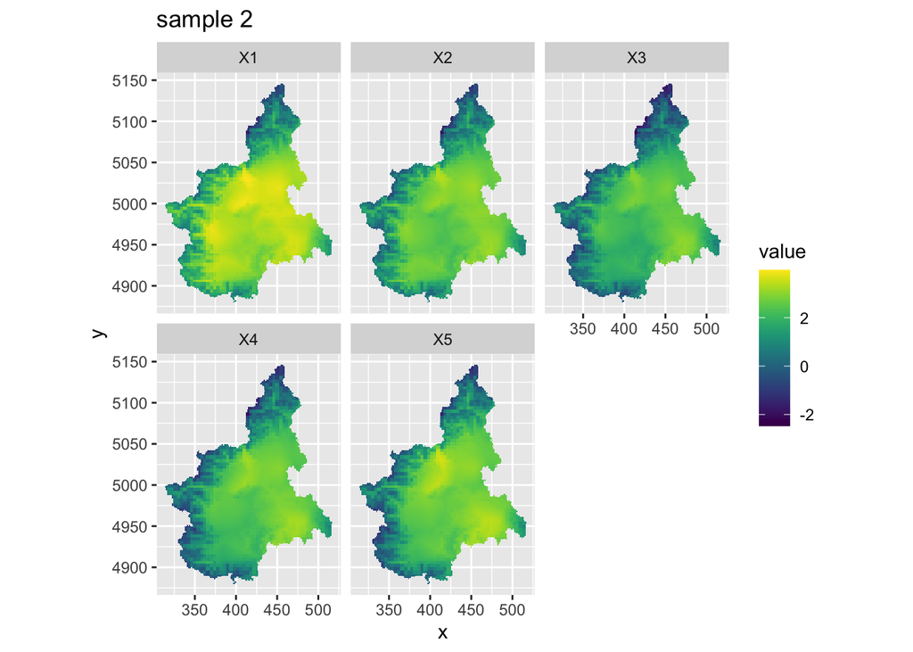

```r
p1 = data.frame(coordinates(pxl),
           matrix(samples[[1]]$log_scale, ncol = 5, byrow = T)) %>%
  pivot_longer(-c(x,y)) %>%
  ggplot() + geom_tile(aes(x,y,fill = value)) + facet_wrap(.~name) +
  scale_fill_viridis() + ggtitle("sample 1") +
  coord_equal()
p2 =  data.frame(coordinates(pxl),
           matrix(samples[[2]]$log_scale, ncol = 5, byrow = T)) %>%
  pivot_longer(-c(x,y)) %>%
  ggplot() + geom_tile(aes(x,y,fill = value)) + facet_wrap(.~name) +
  scale_fill_viridis() + ggtitle("sample 2")+
  coord_equal()
```

**Exercise 3:** Use the `predict()` function to inspect the posterior median of the predicted surface in the exponential scale.

# 7 Prediction at the station locations

We might be also interested in comparing the observed values with the prediction of our model.

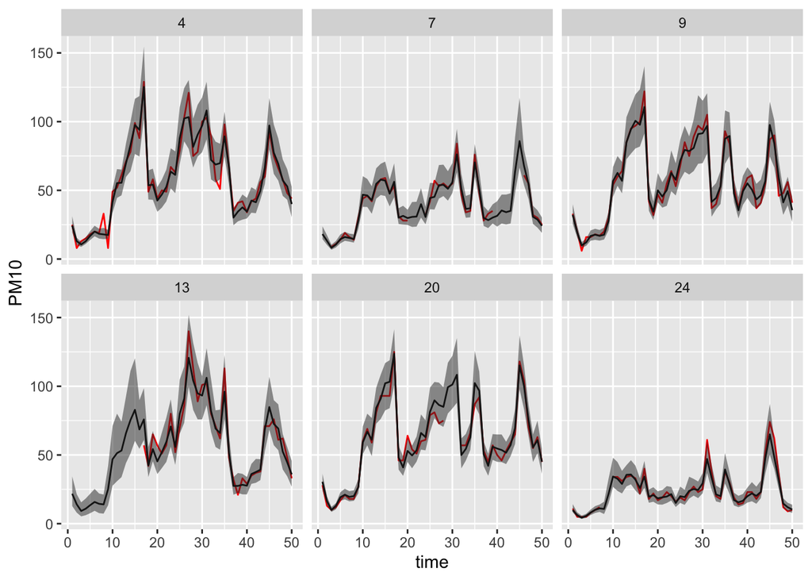

```r
pred_at_station = predict(fit, df, ~exp( Intercept +
                        SPDE +
                        dem + temp))

sel = sample(1:24, 6) %>% sort()
as.data.frame(pred_at_station) %>%
  dplyr::filter(Station.ID %in% sel) %>% ggplot() +
  geom_line(aes(time, PM10, group = Station.ID ), color = "red") +
  geom_line(aes(time, median, group = Station.ID)) +
  geom_ribbon(aes(time,
                  ymin= q0.025,
                  ymax = q0.975,
                  group = Station.ID), alpha = 0.5) +
  facet_wrap(.~Station.ID)
```

**Exercise 4:** Fit the model without covariates and using all the covariates in the dataset `df`. Look at the predicted values at the station locations. Use the model choice criteria to compare the models.

Cameletti, M., F. Lindgren, D. Simpson, and H. Rue. 2013. “Spatio-Temporal Modeling of Particulate Matter Concentration Through the SPDE Approach.” *Adv Stat Anal.* 97.